# Module 3 - Programming Assignment

This is the notebook for the Module 3 Programming Assignment.

Here are a few tips for using the iPython HTML notebook:

1. You can use tab . Try le<<tab> and see the available functions.
2. You can change the type of cell by picking "Code" or "Markdown" from the menu at the left.
3. If you keep typing in a Markdown text area, you will eventually get scroll bars. To prevent this, hit return when you come to the end of the window. Only a double return creates a new paragraph.
4. You can find out more about Markdown text here: http://daringfireball.net/projects/markdown/ (Copy this link and put it in another tab for reference--Don't click it or you'll leave your notebook!).
5. Every so often, restart the kernel, clear all output and run all code cells so you can be certain that you didn't define something out of order.

**You should rename this notebook to be <your JHED id>_PR3.ipynb** Do it right now.

**Make certain the entire notebook executes before you submit it.** (See Hint #5 above)

Change the following variables:

```python
name = "Shehzad Qureshi"
jhed_id = "squresh6"
if name == "Student Name" or jhed_id == "sname1":
    raise Exception( "Change the name and/or JHED ID...preferrably to yours.")
```

Add whatever additional imports you require here. Stick with the standard libraries and those required by the class. The import gives you access to these functions: http://ipython.org/ipython-doc/stable/api/generated/IPython.core.display.html (Copy this link) Which, among other things, will permit you to display HTML as the result of evaluated code (see HTML() or display_html()).

```python
import networkx as nx
from copy import deepcopy
from operator import itemgetter
import matplotlib.pyplot as plt
%matplotlib inline
```

## CSP: Map Coloring

In this programming assignment, you will be using your new understanding Constraint Satisfaction Problems to color random maps. As we know from the [Four Color Theorem](http://en.wikipedia.org/wiki/Four_color_theorem) any division of a plane into contiguous regions can be colored such that no two adjacent regions are the same color by using only four colors.

From the book, we know that we can translate this into a CSP where the map is represented as a [planar graph](http://en.wikipedia.org/wiki/Planar_graph) where the goal is to color all the nodes such that no adjacent nodes are colored the same color.

`def color_map( world)`

where world is a Tuple of (V,E) where V is a vertices list [n1, n2, n3, n4, ...] and E is an edge list [(n1, n3), (n4, n7), ...]. You may want to convert the Edge list to an Adjacency list inside color_map() or not. It's up to you. Each $n_i$ can be a string ("France") or a node number (7).

color_map should return a Dict {n1: "color1", n2: "color2", ...}

## What to color?

There are two possibilies:

1. If your computational geometry is up to snuff, you can generate random maps. These are essentially [Delauney Triangulations](http://en.wikipedia.org/wiki/Delaunay_triangulation) of randomly generated points (where points are the centers of the regions in the map). Color maps of varying sizes (10 nodes, 50 nodes, 100 nodes).
2. You can convert real maps into planar graphs. For your testing, you should use the [Counties of Connecticut](http://quickfacts.census.gov/qfd/maps/connecticut_map.html). You then must color in the [Countries of Europe](http://www.worldatlasbook.com/europe/europe-political-map.html). Do not confuse regions with countries. For example, Northen Ireland should be colored the same as the United Kingdom (they are together Great Britain). Additionally, neighboring islands that are different countries, shouldn't be colored the same.

Side question...do these maps **require** four colors?

## What CSP Algorithms?

You will need to implement **backtracking** and **forward checking**. You will also need to implement **Minimum Remaining Values** or **Degree Heuristic** to pick variables (tell me which one) and **Least Constraining Value** to pick values. Break ties in ascending order (least to most).

I suggest you implement backtracking then forward checking then either minimum remaining values or degree heuristic then least constraining value. This maximizes partial credit should you be unable to complete everything. Only submit a working progam (if you make it through backtracking and forward checking but don't get to the others, remove their code). Please change the "?" below into "yes" or "no" indicating which elements you were able to implement:

```
backtracking: yes
forward checking: yes
minimum remaining values: yes
degree heuristic: yes (optional)
least contraining value: yes
```

Your code should print out *traces* (or debugging) of what it is doing so that I can see the operation of the algorithm.

You can put your helper functions and markdown documentation in cells below here. As before, your Markdown documentation should indicate both what the function does and explains the concept behind the algorithm (or contribution to the algorithm) that is being implemented (where appropriate...not all helper functions will represent a concept in the algorithm). For example, wherever and however backtracking is implemented, the important and role of backtracking in the algorithm should be explained. Similarly everything else.

Your code should print out *traces* (or debugging) of what it is doing so that we can see the operation of the algorithm (Note that because of the way that IPython works, this will slow things down a bit). You're more than welcome to develop in a regular IDE, paste functions into the notebook and add Markdown commentary later...just make sure you do it).

You can put your helper functions and markdown documentation in cells below here:

**Representing a Constraint Satisfaction Problem**

A constraint satisfaction problem (CSP) consists of a set of variables (V), a set of domains (D) for each variable containing a set of values assignable to the variable, and a set of constraints (C). CSP = (V, D, C).

Variables will be represented as a simple list. The type of variable should be irrevelant, be it strings or integers or objects.

Domains will be represented by a dictionary. Each key in the dictionary shall be a variable and the values of each key shall be the domain of that variable.

Constraints will be represented by an adjacency list in the form of a dictionary. Each key shall be a variable in the problem and the values for each key shall be a set of neighbor nodes. We will use a set to eliminate the possibility of duplicates in the event the input is a digraph.

We will now write helper functions to assist with a basic backtracking-search algorithm, adapted from *Artificial Intelligence: A Modern Approach*.

*function* **check_completeness**

We will need to check if the current solution is complete. This is as simple as checking if the solution has assigned values to every variable in the problem.

```python
def check_completeness(solution, variables):
    return True if len(solution) == len(variables) else False
```

*function* **static_variable_selection**

For our variable selection heuristic, this will be a simple function that returns the first unassigned variable in the list.

```python
def static_variable_selection(solution, csp, debug=True):
    unassigned_variables = [x for x in csp[0] if x not in solution]
    variable = unassigned_variables[0]
    if debug: print "  Selected variable: {0}".format(variable)
    return variable
```

*function* **static_domain_selection**

For our domain-value selection heurisitc, this will be a simple function that returns the value in a static ordering, e.g. (1, 2, 3, 4).

```python
def static_domain_selection(variable, assignment, csp, debug=True):
    for domain_value in csp[1][variable]:
        if debug: print "  Selected value {0} for {1}".format(domain_value, variable)
        yield domain_value
```

*function* **check_value_consistency**

We will need to check if assigning a value to a variable will conflict with our current assignments.

```python
def check_value_consistency(variable, value, assignment, constraints, debug=True):
    if assignment is None: return False
    for v in constraints:
        if v in assignment:
            if value is assignment[v]:
                if debug: print "    {0} : {1} conflicts with {2} : {3}".format(variable, value, v, assignment[v])
                return False
    return True
```

*function* **no_inference**

A future template for checking inference in the search. This function does nothing.

```python
def no_inference(csp, variable, value, assignment, debug=True):
    return True
```

*function* **backtrack**

Our recurse backtrack function. Assignment is an empty dictionary which will hold the current solution. csp is a CSP tuple (V, D, C). params are the heurisitcs, which are configurable by the caller.

The algorithm works by using a depth-first search to assign values to variables based on certain heuristics. If a value cannot be assigned, it *backtracks* to the previous value assignment and tries a different combination. It does this recursively until a solution is found, if there is one.

```python
def backtrack(assignment, csp, params, debug=True):
    select_unassigned_variable, order_domain_values, inference = params
    if debug: print "Solution: {0}".format(assignment)
    if check_completeness(assignment, csp[0]): return True, assignment
    variable = select_unassigned_variable(assignment, csp, debug=debug)
    for value in order_domain_values(variable, assignment, csp, debug):
        if check_value_consistency(variable, value, assignment, csp[2][variable], debug=debug):
            assignment[variable], m_csp = value, deepcopy(csp)
            if inference(csp, variable, value, assignment, debug=debug):
                result, assignment = backtrack(deepcopy(assignment), csp, params, debug=debug)
                if result: return True, assignment
            del assignment[variable]
            csp = m_csp
    return False, assignment
```

*function* **backtracking_search**

This is the main entry point for the search algorithm. params is changeable depending on what heuristics we want to implement.

```python
def backtracking_search(csp, params, debug=True):
    solution = dict()
    return backtrack(solution, csp, params, debug=debug)
```

*function* **get_adjacency_list**

We need a way of converting nodes and edges provided into an adjacency list. This function loops through the list of edges and gathers the unique neighboring nodes for each node and stores it in a list. Each list is then added to a dictionary which holds the adjacency list for the CSP.

```python
def get_adjacency_list(nodes, edges):
    adjacency_list = dict()
    for node in nodes:
        aList = set()
        [aList.add(x) for x, y in edges if x != node and y == node]
        [aList.add(y) for x, y in edges if y != node and x == node]
        adjacency_list[node] = aList
    return adjacency_list
```

We will need placeholders for future functions, blame IPython for its iterative approach.

```python
def minimum_remaining_values():
    pass

def least_contraining_value():
    pass

def forward_checking():
    pass
```

*function* **color_map**

This is the public function that will color a map given the nodes and edges as a tuple. Colors is changeable for testing purposes. The default heuristics are **Minimum Remaining Values**, **Least Constraining Value** and **Forward Checking**. Debugging is turned on by default as well which will provide traces as the algorithm progresses.

```python
def color_map(world, colors=["blue", "green", "red", "yellow"], params=(minimum_remaining_values, least_contraining_value, forward_checking), debug=True):
    variables = world[0]
    domains = dict([(x, colors) for x in variables])
    constraints = get_adjacency_list(world[0], world[1])
    result, solution = backtracking_search((variables, domains, constraints), params, debug=debug)
    if not result: print "No Solution"
    else: return solution
```

*function* **draw_color_map**

We need an easy way of visually checking for correctness. We can use NetworkX to plot a graph and color the nodes as appropriate. Laying the nodes out in a geographically correct manner will be left for later if time permits.

```python
def draw_color_map(world, colors, pos=None):
    if colors is None: return
    fig = plt.figure()
    G = nx.Graph()
    if pos is None:
        pos = nx.spring_layout(G)
    G.add_nodes_from(world[0])
    G.add_edges_from(world[1])
    node_colors = [colors[x] for x in G.nodes()]
    nx.draw(G, node_color=node_colors, node_size=700, alpha=0.5)
    plt.axis('off')
    fig.set_size_inches(8, 8)
    plt.show()
```

**Testing**

First we will test with the counties of Connecticut. This function was re-used from the link provided in the discussion forums.

```python
def connecticut_map():
    nodes = ["fairfield", "litchfield", "new haven", "hartford", "middlesex", "tolland", "new london", "windham"]
    edges = [("fairfield", "litchfield"), ("fairfield", "new haven"),
             ("litchfield", "new haven"), ("litchfield", "hartford"),
             ("new haven", "hartford"), ("new haven", "middlesex"),
             ("hartford", "middlesex"), ("hartford", "tolland"), ("hartford", "new london"),
             ("middlesex", "new london"),
             ("tolland", "new london"), ("tolland", "windham"),
             ("new london", "windham")]
    return (nodes, edges)
```

```
Solution: {}
  Selected variable: fairfield
  Selected value blue for fairfield
Solution: {'fairfield': 'blue'}
  Selected variable: litchfield
  Selected value blue for litchfield
    litchfield : blue conflicts with fairfield : blue
  Selected value green for litchfield
Solution: {'litchfield': 'green', 'fairfield': 'blue'}
  Selected variable: new haven
  Selected value blue for new haven
    new haven : blue conflicts with fairfield : blue
  Selected value green for new haven
    new haven : green conflicts with litchfield : green
  Selected value red for new haven
Solution: {'litchfield': 'green', 'new haven': 'red', 'fairfield': 'blue'}
  Selected variable: hartford
  Selected value blue for hartford
Solution: {'litchfield': 'green', 'new haven': 'red', 'hartford': 'blue', 'fairfield': 'blue'}
  Selected variable: middlesex
  Selected value blue for middlesex
    middlesex : blue conflicts with hartford : blue
  Selected value green for middlesex
Solution: {'litchfield': 'green', 'hartford': 'blue', 'new haven': 'red', 'middlesex': 'green', 'fairfield': 'blue'}
  Selected variable: tolland
  Selected value blue for tolland
    tolland : blue conflicts with hartford : blue
  Selected value green for tolland
Solution: {'new haven': 'red', 'middlesex': 'green', 'litchfield': 'green', 'fairfield': 'blue', 'tolland': 'green', 'hartford': 'blue'}
  Selected variable: new london
  Selected value blue for new london
    new london : blue conflicts with hartford : blue
  Selected value green for new london
    new london : green conflicts with middlesex : green
  Selected value red for new london
Solution: {'new london': 'red', 'new haven': 'red', 'middlesex': 'green', 'litchfield': 'green', 'fairfield': 'blue', 'tolland': 'green', 'hartford': 'blue'}
  Selected variable: windham
  Selected value blue for windham
Solution: {'new london': 'red', 'new haven': 'red', 'middlesex': 'green', 'litchfield': 'green', 'fairfield': 'blue', 'tolland': 'green', 'windham': 'blue', 'hartford': 'blue'}
```

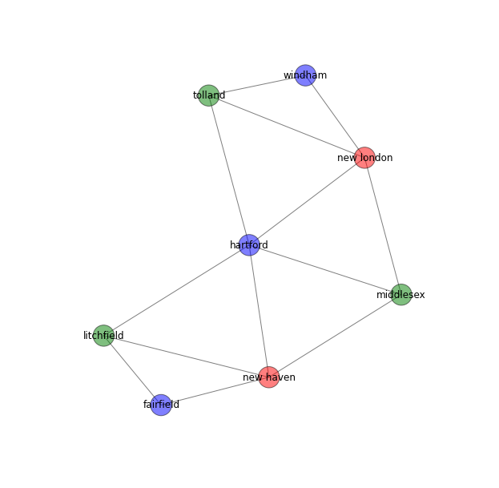

```python
world = connecticut_map()
solution = color_map(world, params=(static_variable_selection, static_domain_selection, no_inference))
draw_color_map(world, solution)
```

Seems like only three colors are needed for counties of Connecticut!

This is a function for the map of Ireland, also reused from the discussion board.

```python
def ireland_map():
    nodes = ["Carlow", "Cavan", "Clare", "Cork", "Donegal", "Dublin", "Galway", "Kerry", "Kildare", "Kilkenny",
             "Laois", "Leitrim", "Limerick", "Longford", "Louth", "Mayo", "Meath", "Monaghan", "Offaly",
             "Roscommon", "Sligo", "Tipperary", "Waterford", "Westmeath", "Wexford", "Wicklow"]
    edges = [("Carlow", "Wexford"),("Carlow", "Kilkenny"),("Carlow", "Laois"),("Carlow", "Kildare"),("Carlow", "Wicklow"),
             ("Cavan", "Monaghan"),("Cavan", "Meath"),("Cavan", "Westmeath"),("Cavan", "Longford"),("Cavan", "Leitrim"),
             ("Clare", "Limerick"),("Clare", "Tipperary"),("Clare", "Galway"),
             ("Cork", "Kerry"),("Cork", "Limerick"),("Cork", "Tipperary"),("Cork", "Waterford"),
             ("Donegal", "Leitrim"),
             ("Dublin", "Wicklow"),("Dublin", "Kildare"),("Dublin", "Meath"),
             ("Galway", "Tipperary"),("Galway", "Offaly"),("Galway", "Roscommon"),("Galway", "Mayo"),
             ("Kerry", "Limerick"),
             ("Kildare", "Wicklow"),("Kildare", "Laois"),("Kildare", "Offaly"),("Kildare", "Meath"),
             ("Kilkenny", "Waterford"),("Kilkenny", "Tipperary"),("Kilkenny", "Laois"),("Kilkenny", "Wexford"),
             ("Laois", "Tipperary"),("Laois", "Offaly"),
             ("Leitrim", "Longford"),("Leitrim", "Roscommon"),("Leitrim", "Sligo"),
             ("Limerick", "Tipperary"),
             ("Longford", "Westmeath"),("Longford", "Roscommon"),
             ("Louth", "Meath"),("Louth", "Monaghan"),
             ("Mayo", "Roscommon"),("Mayo", "Sligo"),
             ("Meath", "Offaly"),("Meath", "Westmeath"),
             ("Offaly", "Tipperary"),("Offaly", "Roscommon"),("Offaly", "Westmeath"),
             ("Roscommon", "Sligo"),("Roscommon", "Westmeath"),
             ("Tipperary", "Waterford"),
             ("Wexford", "Wicklow")]
    return (nodes, edges)
```

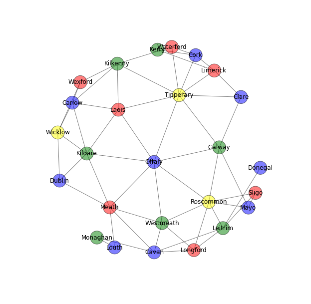

```python
world = ireland_map()
solution = color_map(world, params=(static_variable_selection, static_domain_selection, no_inference), debug=False)
draw_color_map(world, solution)
```

This is the map of Europe, reused from the discussion board and slightly modified.

```python
def europe_map():
    nodes = ["Iceland","Ireland","United Kingdom","Portugal","Spain","France","Andorra","Monaco","Belgium",
           "Luxembourg","Germany","Switzerland","Italy","Netherlands","Liechtenstein","Austria","Malta","Cyprus",
           "Vatican City","San Marino","Slovenia","Denmark","Poland","Czech Republic","Norway","Sweden","Finland",
           "Russia","Slovakia","Hungary","Croatia","Lithuania","Belarus","Ukraine","Estonia","Latvia","Georgia",
           "Azerbaijan","Armenia","Turkey","Moldova","Romania","Bosnia & Herzegovina","Serbia","Bulgaria",
           "Montenegro","Kosovo","Macedonia","Albania","Greece"]
    edges = [("Iceland","United Kingdom"),("Iceland","Ireland"),("Iceland","Norway"),
             ("Norway","Denmark"),("Norway","United Kingdom"),("Norway","Sweden"),("Norway","Netherlands"),
             ("Sweden","Finland"),("Sweden","Denmark"),("Sweden","Estonia"),("Sweden","Latvia"),("Sweden","Lithuania"),("Sweden","Poland"),
             ("Finland","Estonia"),("Finland","Russia"),
             ("Estonia","Russia"),("Estonia","Latvia"),
             ("Latvia","Lithuania"),("Latvia","Belarus"),("Latvia","Russia"),
             ("Lithuania","Belarus"),("Lithuania","Poland"),
             ("United Kingdom","Ireland"),("United Kingdom","France"),("United Kingdom","Belgium"),("United Kingdom","Netherlands"),
             ("Denmark","United Kingdom"),("Denmark","Germany"),("Denmark","Poland"),("Denmark","Netherlands"),
             ("Portugal","Iceland"),("Portugal","Spain"),
             ("Spain","Andorra"),("Spain","France"),("Spain","Ireland"),("Spain","United Kingdom"),("Spain","Monaco"),("Spain","Italy"),
             ("France","Belgium"),("France","Germany"),("France","Switzerland"),("France","Italy"),("France","Monaco"),("France","Luxembourg"),
             ("Belgium","Netherlands"),("Belgium","Luxembourg"),("Belgium","Germany"),
             ("Germany","Luxembourg"),("Germany","Switzerland"),("Germany","Austria"),("Germany","Poland"),("Germany","Czech Republic"),
             ("Poland","Czech Republic"),("Poland","Slovakia"),("Poland","Belarus"),("Poland","Ukraine"),
             ("Belarus","Ukraine"),("Belarus","Russia"),
             ("Switzerland","Italy"),("Switzerland","Austria"),("Switzerland","Liechtenstein"),
             ("Liechtenstein","Austria"),
             ("Austria","Czech Republic"),("Austria","Slovakia"),("Austria","Hungary"),("Austria","Slovenia"),("Austria","Italy"),
             ("Slovakia","Czech Republic"),("Slovakia","Hungary"),("Slovakia","Ukraine"),
             ("Ukraine","Russia"),("Ukraine","Moldova"),("Ukraine","Turkey"),
             ("Italy","Monaco"),("Italy","Vatican City"),("Italy","Slovenia"),("Italy","Croatia"),("Italy","Malta"),("Italy","San Marino"),
             ("Slovenia","Croatia"),("Slovenia","Hungary"),
             ("Hungary","Romania"),("Hungary","Serbia"),
             ("Romania","Serbia"),("Romania","Bulgaria"),("Romania","Moldova"),("Romania","Turkey"),
             ("Moldova","Ukraine"),("Croatia","Bosnia & Herzegovina"),("Croatia","Serbia"),("Croatia","San Marino"),
             ("Bosnia & Herzegovina","Montenegro"),("Bosnia & Herzegovina","Serbia"),("Bosnia & Herzegovina","San Marino"),
             ("Montenegro","Serbia"),("Montenegro","Kosovo"),("Montenegro","Albania"),
             ("Kosovo","Serbia"),("Kosovo","Albania"),("Kosovo","Macedonia"),("Serbia","Bulgaria"),("Serbia","Romania"),
             ("Albania","Greece"),("Albania","Italy"),("Albania","Macedonia"),
             ("Macedonia","Greece"),("Macedonia","Serbia"),("Macedonia","Bulgaria"),
             ("Bulgaria","Romania"),("Bulgaria","Turkey"),("Bulgaria","Greece"),("Romania","Ukraine"),
             ("Greece","Turkey"),("Greece","Malta"),("Greece","Cyprus"),
             ("Turkey","Cyprus"),("Turkey","Ukraine"),("Turkey","Georgia"),("Turkey","Armenia"),
             ("Armenia","Georgia"),("Armenia","Azerbaijan"),("Georgia","Azerbaijan")]
    return (nodes, edges)
```

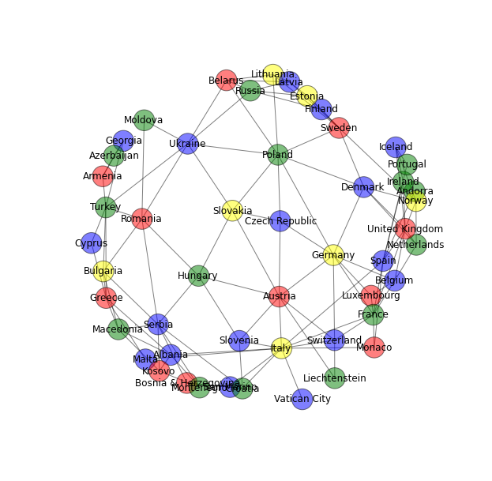

```python
world = europe_map()
solution = color_map(world, params=(static_variable_selection, static_domain_selection, no_inference), debug=False)
draw_color_map(world, solution)
```

**Forward Checking**

```python
def forward_checking(csp, variable, value, assignment, debug=True):
    unassigned_neighbors = [y for y in csp[2][variable] if y not in assignment]
    for x in unassigned_neighbors:
        if value in csp[1][x]:
            if debug: print "    Removing {0} from {1}".format(value, x)
            csp[1][x] = [c for c in csp[1][x] if c is not value]
        if len(csp[1][x]) == 0: return False
    return True
```

```
Solution: {}
  Selected variable: fairfield
  Selected value blue for fairfield
    Removing blue from litchfield
    Removing blue from new haven
Solution: {'fairfield': 'blue'}
  Selected variable: litchfield
  Selected value green for litchfield
    Removing green from new haven
    Removing green from hartford
Solution: {'litchfield': 'green', 'fairfield': 'blue'}
  Selected variable: new haven
  Selected value red for new haven
    Removing red from middlesex
    Removing red from hartford
Solution: {'litchfield': 'green', 'new haven': 'red', 'fairfield': 'blue'}
  Selected variable: hartford
  Selected value blue for hartford
    Removing blue from tolland
    Removing blue from new london
    Removing blue from middlesex
Solution: {'litchfield': 'green', 'new haven': 'red', 'hartford': 'blue', 'fairfield': 'blue'}
  Selected variable: middlesex
  Selected value green for middlesex
    Removing green from new london
Solution: {'litchfield': 'green', 'hartford': 'blue', 'new haven': 'red', 'middlesex': 'green', 'fairfield': 'blue'}
  Selected variable: tolland
  Selected value green for tolland
    Removing green from windham
Solution: {'new haven': 'red', 'middlesex': 'green', 'litchfield': 'green', 'fairfield': 'blue', 'tolland': 'green', 'hartford': 'blue'}
  Selected variable: new london
  Selected value red for new london
    Removing red from windham
Solution: {'new london': 'red', 'new haven': 'red', 'middlesex': 'green', 'litchfield': 'green', 'fairfield': 'blue', 'tolland': 'green', 'hartford': 'blue'}
  Selected variable: windham
  Selected value blue for windham
Solution: {'new london': 'red', 'new haven': 'red', 'middlesex': 'green', 'litchfield': 'green', 'fairfield': 'blue', 'tolland': 'green', 'windham': 'blue', 'hartford': 'blue'}
```

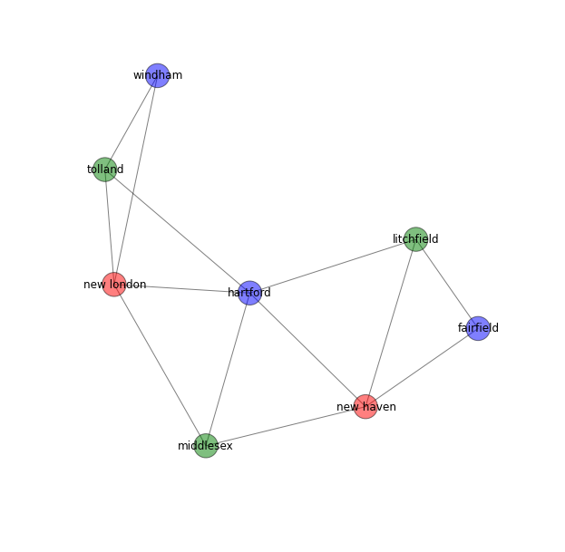

```python
world = connecticut_map()
solution = color_map(world, params=(static_variable_selection, static_domain_selection, forward_checking))
draw_color_map(world, solution)
```

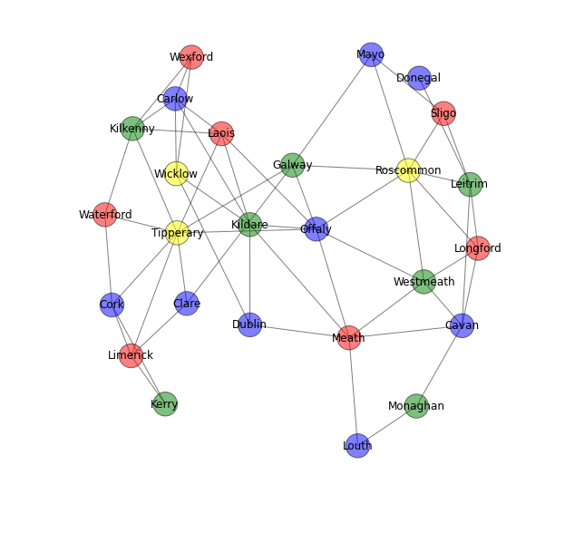

```python
world = ireland_map()
solution = color_map(world, params=(static_variable_selection, static_domain_selection, forward_checking), debug=False)
draw_color_map(world, solution)
```

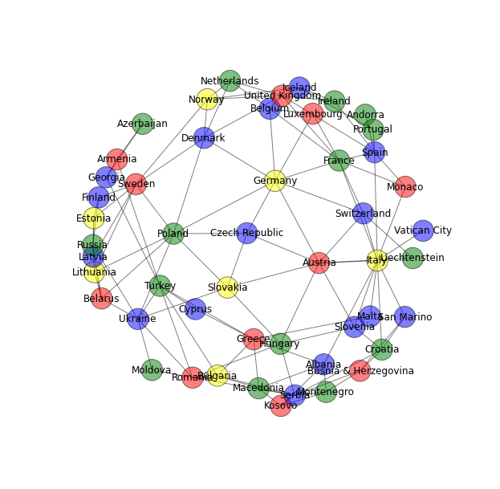

```python
world = europe_map()
solution = color_map(world, params=(static_variable_selection, static_domain_selection, forward_checking), debug=False)
draw_color_map(world, solution)
```

**Minimum Remaining Value**

This heuristic, also known as the most constrained variable, is intended to pick a variable that is most likely to fail first, thereby speeding up the backtracking process.

```python
def minimum_remaining_values(solution, csp, debug=True):
    unassigned_variables = [x for x in csp[0] if x not in solution]
    variable_domain_count = [(x, len(csp[1][x])) for x in unassigned_variables]
    variables = sorted(variable_domain_count, key=itemgetter(1))
    if debug: print "  Selected variable {0} with value count {1}".format(variables[0][0], variables[0][1])
    return variables[0][0]
```

```
Solution: {}
  Selected variable fairfield with value count 4
  Selected value blue for fairfield
    Removing blue from litchfield
    Removing blue from new haven
Solution: {'fairfield': 'blue'}
  Selected variable litchfield with value count 3
  Selected value green for litchfield
    Removing green from new haven
    Removing green from hartford
Solution: {'litchfield': 'green', 'fairfield': 'blue'}
  Selected variable new haven with value count 2
  Selected value red for new haven
    Removing red from middlesex
    Removing red from hartford
Solution: {'litchfield': 'green', 'new haven': 'red', 'fairfield': 'blue'}
  Selected variable hartford with value count 2
  Selected value blue for hartford
    Removing blue from tolland
    Removing blue from new london
    Removing blue from middlesex
Solution: {'litchfield': 'green', 'new haven': 'red', 'hartford': 'blue', 'fairfield': 'blue'}
  Selected variable middlesex with value count 2
  Selected value green for middlesex
    Removing green from new london
Solution: {'litchfield': 'green', 'hartford': 'blue', 'new haven': 'red', 'middlesex': 'green', 'fairfield': 'blue'}
  Selected variable new london with value count 2
  Selected value red for new london
    Removing red from windham
    Removing red from tolland
Solution: {'new london': 'red', 'new haven': 'red', 'middlesex': 'green', 'litchfield': 'green', 'fairfield': 'blue', 'hartford': 'blue'}
  Selected variable tolland with value count 2
  Selected value green for tolland
    Removing green from windham
Solution: {'new london': 'red', 'new haven': 'red', 'middlesex': 'green', 'litchfield': 'green', 'fairfield': 'blue', 'tolland': 'green', 'hartford': 'blue'}
  Selected variable windham with value count 2
  Selected value blue for windham
Solution: {'new london': 'red', 'new haven': 'red', 'middlesex': 'green', 'litchfield': 'green', 'fairfield': 'blue', 'tolland': 'green', 'windham': 'blue', 'hartford': 'blue'}
```

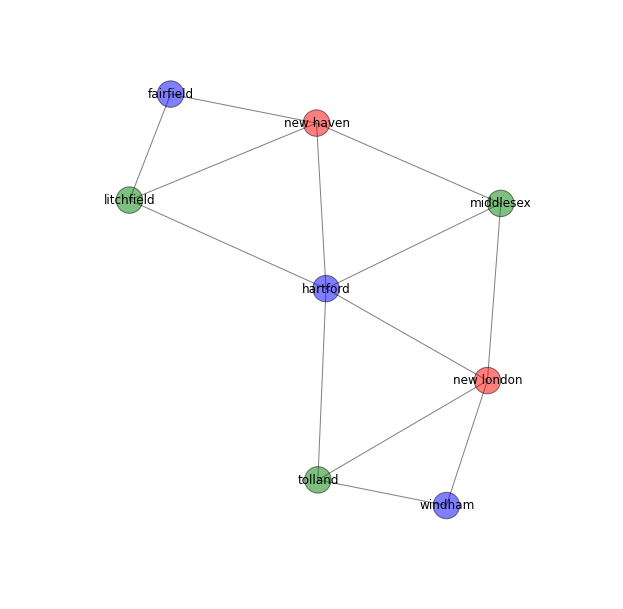

```python
world = connecticut_map()
solution = color_map(world, params=(minimum_remaining_values, static_domain_selection, forward_checking))
draw_color_map(world, solution)
```

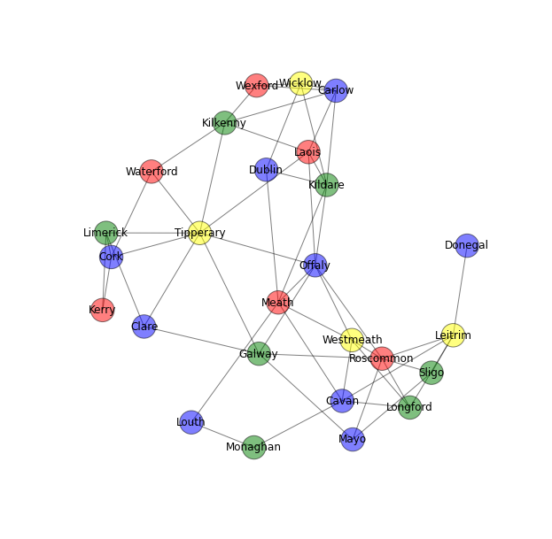

```python
world = ireland_map()
solution = color_map(world, params=(minimum_remaining_values, static_domain_selection, forward_checking), debug=False)
draw_color_map(world, solution)
```

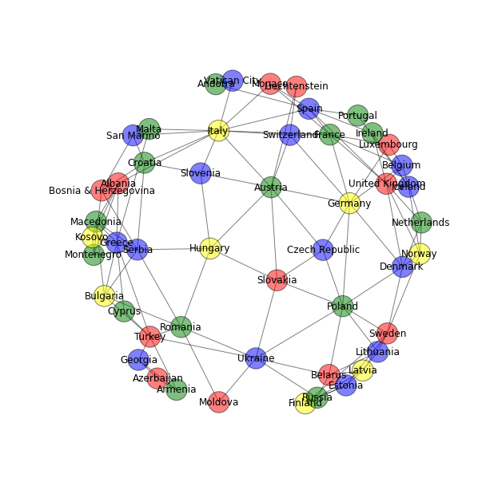

```python
world = europe_map()
solution = color_map(world, params=(minimum_remaining_values, static_domain_selection, forward_checking), debug=False)
draw_color_map(world, solution)
```

**Least Constraining Value**

This heuristic will select the value that is most common amongst neighbor nodes.

```python
def least_contraining_value(variable, assignment, csp, debug=True):
    neighbors = csp[2][variable]
    value_count = []
    for value in csp[1][variable]:
        count = 0
        for neighbor in neighbors:
            if value in csp[1][neighbor]:
                count = count + 1
        value_count.append((value, count))
    counted = sorted(value_count, key=itemgetter(1), reverse=True)
    for value, count in counted:
        if debug: print "  Selected value {0} for {1}".format(value, variable)
        yield value
```

```
Solution: {}
  Selected variable fairfield with value count 4
  Selected value blue for fairfield
    Removing blue from litchfield
    Removing blue from new haven
Solution: {'fairfield': 'blue'}
  Selected variable litchfield with value count 3
  Selected value green for litchfield
    Removing green from new haven
    Removing green from hartford
Solution: {'litchfield': 'green', 'fairfield': 'blue'}
  Selected variable new haven with value count 2
  Selected value red for new haven
    Removing red from middlesex
    Removing red from hartford
Solution: {'litchfield': 'green', 'new haven': 'red', 'fairfield': 'blue'}
  Selected variable hartford with value count 2
  Selected value yellow for hartford
    Removing yellow from tolland
    Removing yellow from new london
    Removing yellow from middlesex
Solution: {'litchfield': 'green', 'new haven': 'red', 'hartford': 'yellow', 'fairfield': 'blue'}
  Selected variable middlesex with value count 2
  Selected value blue for middlesex
    Removing blue from new london
Solution: {'litchfield': 'green', 'hartford': 'yellow', 'new haven': 'red', 'middlesex': 'blue', 'fairfield': 'blue'}
  Selected variable new london with value count 2
  Selected value green for new london
    Removing green from windham
    Removing green from tolland
Solution: {'new london': 'green', 'new haven': 'red', 'middlesex': 'blue', 'litchfield': 'green', 'fairfield': 'blue', 'hartford': 'yellow'}
  Selected variable tolland with value count 2
  Selected value blue for tolland
    Removing blue from windham
Solution: {'new london': 'green', 'new haven': 'red', 'middlesex': 'blue', 'litchfield': 'green', 'fairfield': 'blue', 'tolland': 'blue', 'hartford': 'yellow'}
  Selected variable windham with value count 2
  Selected value red for windham
Solution: {'new london': 'green', 'new haven': 'red', 'middlesex': 'blue', 'litchfield': 'green', 'fairfield': 'blue', 'tolland': 'blue', 'windham': 'red', 'hartford': 'yellow'}
```

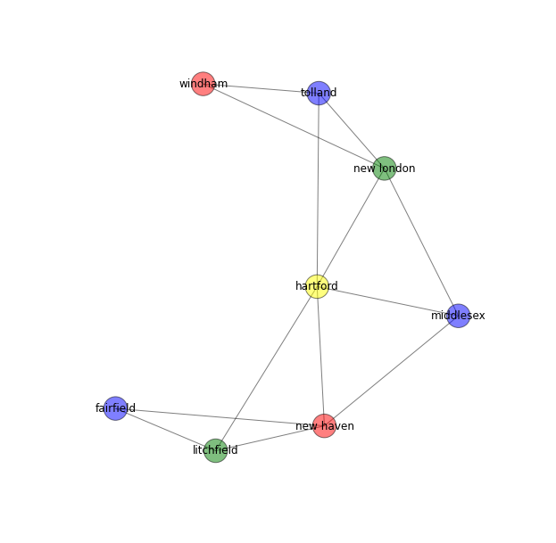

```python
world = connecticut_map()
solution = color_map(world, params=(minimum_remaining_values, least_contraining_value, forward_checking))
draw_color_map(world, solution)
```

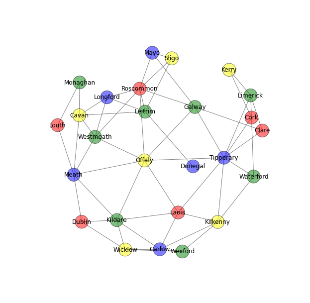

```python
world = ireland_map()
solution = color_map(world, params=(minimum_remaining_values, least_contraining_value, forward_checking), debug=False)
draw_color_map(world, solution)
```

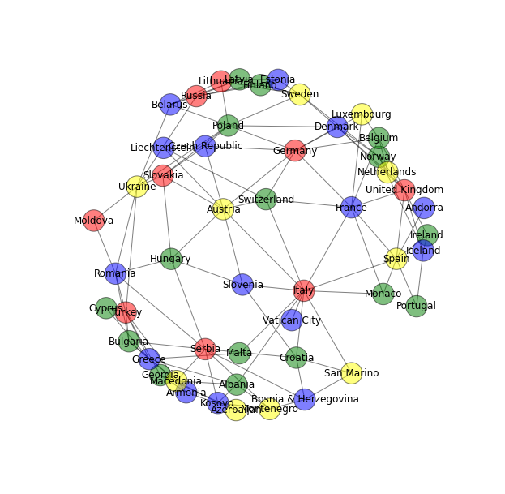

```python
world = europe_map()
solution = color_map(world, params=(minimum_remaining_values, least_contraining_value, forward_checking), debug=False)
draw_color_map(world, solution)
```

**Degree Heuristic**

This is an alternative to Minimum Remaining Values as a heuristic to pick a variable. This will pick the variable with the highest number of constraints.

```python
def degree_heuristic(solution, csp, debug=True):
    unassigned_variables = [x for x in csp[0] if x not in solution]
    variable_domain_count = [(x, len(csp[2][x])) for x in unassigned_variables]
    variables = sorted(variable_domain_count, key=itemgetter(1), reverse=True)
    if debug: print "  Selected variable {0} with constraint count {1}".format(variables[0][0], variables[0][1])
    return variables[0][0]
```

```
Solution: {}
  Selected variable hartford with constraint count 5
  Selected value blue for hartford
    Removing blue from litchfield
    Removing blue from tolland
    Removing blue from new london
    Removing blue from new haven
    Removing blue from middlesex
Solution: {'hartford': 'blue'}
  Selected variable new haven with constraint count 4
  Selected value green for new haven
    Removing green from litchfield
    Removing green from middlesex
    Removing green from fairfield
Solution: {'new haven': 'green', 'hartford': 'blue'}
  Selected variable new london with constraint count 4
  Selected value red for new london
    Removing red from middlesex
    Removing red from windham
    Removing red from tolland
Solution: {'new london': 'red', 'new haven': 'green', 'hartford': 'blue'}
  Selected variable litchfield with constraint count 3
  Selected value red for litchfield
    Removing red from fairfield
Solution: {'litchfield': 'red', 'new london': 'red', 'new haven': 'green', 'hartford': 'blue'}
  Selected variable middlesex with constraint count 3
  Selected value yellow for middlesex
Solution: {'litchfield': 'red', 'hartford': 'blue', 'new london': 'red', 'new haven': 'green', 'middlesex': 'yellow'}
  Selected variable tolland with constraint count 3
  Selected value green for tolland
    Removing green from windham
Solution: {'new london': 'red', 'new haven': 'green', 'middlesex': 'yellow', 'litchfield': 'red', 'tolland': 'green', 'hartford': 'blue'}
  Selected variable fairfield with constraint count 2
  Selected value yellow for fairfield
Solution: {'new london': 'red', 'new haven': 'green', 'middlesex': 'yellow', 'litchfield': 'red', 'fairfield': 'yellow', 'tolland': 'green', 'hartford': 'blue'}
  Selected variable windham with constraint count 2
  Selected value yellow for windham
Solution: {'new london': 'red', 'new haven': 'green', 'middlesex': 'yellow', 'litchfield': 'red', 'fairfield': 'yellow', 'tolland': 'green', 'windham': 'yellow', 'hartford': 'blue'}
```

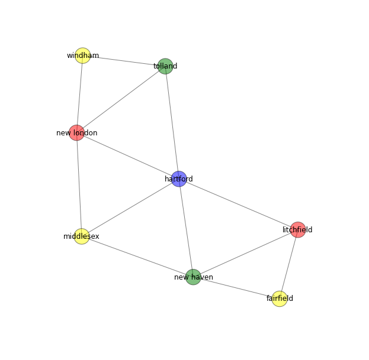

```python
world = connecticut_map()
solution = color_map(world, params=(degree_heuristic, least_contraining_value, forward_checking),)
draw_color_map(world, solution)
```

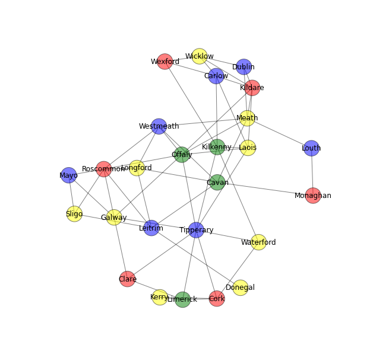

```python
world = ireland_map()
solution = color_map(world, params=(degree_heuristic, least_contraining_value, forward_checking), debug=False)
draw_color_map(world, solution)
```

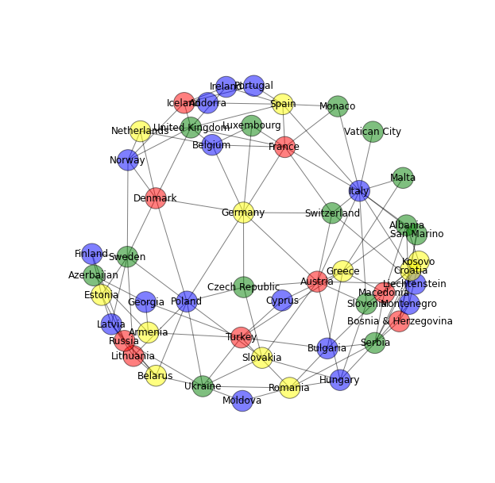

```python
world = europe_map()
solution = color_map(world, params=(degree_heuristic, least_contraining_value, forward_checking), debug=False)
draw_color_map(world, solution)
```

**Random Graphs**

We can use NetworkX to generate random graphs.

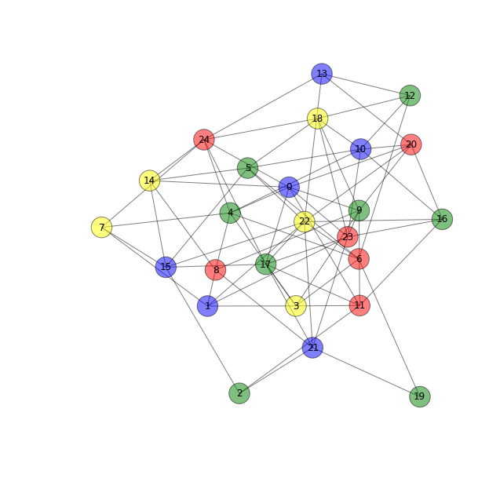

```python
G = nx.gnp_random_graph(25, 0.25)
world = ((G.nodes(),G.edges()))
solution = color_map(world, params=(minimum_remaining_values, least_contraining_value, forward_checking), debug=False)
draw_color_map(world, solution)
```

**Summary**

The Backtracking-Search algorithm is a simple *informed* depth-first search algorithm that assigns values to variables given certain constraints. Once it determines that a value cannot be assigned, it *backtracks* to the previous assignment and tries a different value. This is similar to traversing down a tree until all nodes have values assigned to them that satisfies the given constraints.

This has probably been my favorite algorithm to work with so far, although implementing the backtracking algorithm was a bit harder than I expected. This is probably because of translation errors from psuedocode to actual python code. The psuedocode for the algorithm returns False or Assignments, which in python are two different objects (boolean and dictionary). Once I made the necessary adjustments the algorithm seemed to work like I expected. Another python frustration which I found out the hard way: "is not" =/= "!=". This was especially true when I was converting nodes and edges into an adjacency list and the map of europe was coming up with a near empty adjacency list.

Perhaps one part of CSP that isn't completely clear is the difference between AC-3, Forward Checking and MAC. I believe that AC-3 checks arc-consistency given the current variable and value assignment. Forward Checking removes the current value assignment from unassigned variables which prevents conflicts in future assignments. I think that MAC is a combination of both; it does Forward Checking by removing values from unassigned variables as well as propagates those changes forward like AC-3.

I did have problems with NetworkX and Matplotlib not wanting to plot images. Specifically, some of the images turn out to be incredibly small. If I run the cell again the problem seems to fix itself but it is puzzling why it doesn't work the first time around.

Finally, it seems that it is possible to generate a random graph that cannot be solved by this algorithm, probably because it is too densely connected. This makes me question my algorithm but upon reading the Four Color Theorem, it seems that the requirement be that nodes be adjacent and not at corners, which may be why some graphs cannot be solved with four colors.

```python
# leave this cell for my testing.
```